# BIOM612 Week 5 Lab Handout

Ammar Naqvi and Yuanchao Zhang

2/7/2018

In this week’s lab, we are going to practice with several statistical methods for comparing two samples. These methods can be split into two categories based on their goals:

- Compare two proportions of two samples: Pearson’s Chi-square test, Fisher’s Exact test, and McNemar’s test.
- Compare two distributions of two samples: Kolmogorov-Smirnov test and quantile-quantile plot.

We are going to go through an overview of these methods and practice with each of them individually.

# 1 Overview of statistically comparing two-sample proportions

## 1.1 One-sample versus two-sample statistical methods

The guideline of choosing one-sample or two-sample statistical methods is trivial. When you have two samples, use two-sample method. When you have only one-sample, use one-sample method.

However, the mathematical differences between one-sample and two-sample statistical methods are not very obvious, in a sense that you cannot directly apply one-sample methods to two-sample situations to obtain identical results, and vice versa. You might have already noticed this in the homework 2, where we asked you to compare the proportions of one sample to another sample using one-sample test of proportion. If you use one-sample proportion test, you will obtain a different results from using two-sample proportion test. Even when you use the same one-sample proportion test but take different samples as constant, you obtain different results.

Following is an example of the different results of one-sample and two-sample proportion tests.

```r
# Say we have the following (contingency) table
n_non_smoke_disease <- 35
n_smoke_disease <- 50
n_non_smoke_healthy <- 500
n_smoke_healthy <- 300

disease_smoke_tbl <- data.frame('disease' = c(n_non_smoke_disease, n_smoke_disease),
                                'healthy' = c(n_non_smoke_healthy, n_smoke_healthy))

rownames(disease_smoke_tbl) <- c('non-smoke', 'smoke')

disease_smoke_tbl
```

```
##           disease healthy
## non-smoke      35     500
## smoke          50     300
```

```r
# Then, we compare the disease proportions of smoke and non-smoke people.

# Null hypothesis H_0: p = p0.
# - p is the diease proportion of one condition, non-smoke or smoke.
# - p0 is the disease proportion of the other condition, and we take
#   p0 as constant to perform one-sample proportion test.

# If we use the disease proportion of smoke as p0:
prop.test(x = disease_smoke_tbl['non-smoke', 'disease'], n = sum(disease_smoke_tbl['non-smoke',]),
          p = disease_smoke_tbl['smoke', 'disease'] / sum(disease_smoke_tbl['smoke', ]),
          alternative = 'two.sided', correct = F)
```

[output not shown]

```r
# If we use the disease proportion of non-smoke as p0:
prop.test(x = disease_smoke_tbl['smoke', 'disease'], n = sum(disease_smoke_tbl['smoke',]),
          p = disease_smoke_tbl['non-smoke', 'disease'] / sum(disease_smoke_tbl['non-smoke', ]),
          alternative = 'two.sided', correct = F)
```

[output not shown]

```r
# If we use two-sample proportion test
prop.test(x = as.matrix(disease_smoke_tbl), alternative = 'two.sided', correct = F)
```

```
##
##  2-sample test for equality of proportions without continuity
##  correction
##
## data:  as.matrix(disease_smoke_tbl)
## X-squared = 14.613, df = 1, p-value = 0.000132
## alternative hypothesis: two.sided
## 95 percent confidence interval:
##  -0.11966168 -0.03521148
## sample estimates:
##     prop 1     prop 2
## 0.06542056 0.14285714
```

We will go through some differences between one-sample and two-sample statistical methods in slightly more details.

### 1.1.1 To think about

1. If we run two-sample proportion test without `as.matrix()`, i.e. `prop.test(x = disease_smoke_tbl, alternative = 'two.sided', correct = F)`, what will happen? Is the message given by R helpful? The different R behavior with or without `as.matrix()` is generally because R treats matrix and dataframe differently. If you are not sure about which one to use, read the documentation carefully and generate fake data for testing.

## 1.2 2 x 2 contingency table

Like “coin flip” is a pedagogical example of basic probability theory, 2 by 2 contingency table is the general scenario of two-sample proportion tests. In the above example, `disease_smoke_tbl` is a 2 x 2 contingency table. To make it conform to statistical convention by adding “total” column and row:

```r
# sc represents statistical convention
sc_disease_smoke_tbl <- disease_smoke_tbl
sc_disease_smoke_tbl$total = rowSums(sc_disease_smoke_tbl)
sc_disease_smoke_tbl <- rbind(sc_disease_smoke_tbl, colSums(sc_disease_smoke_tbl))
rownames(sc_disease_smoke_tbl)[3] <- 'total'
sc_disease_smoke_tbl
```

```
##           disease healthy total
## non-smoke      35     500   535
## smoke          50     300   350
## total          85     800   885
```

Most of R two-sample proportion test functions takes in the 2 x 2 contingency table **without** the “total” column and row as input. For example, in the example above, `prop.test()` takes the contingency table `disease_smoke_tbl` as input for two-sample proportion test.

One thing you have to be sure about is which proportions are tested. For example, in the above example of two-sample proportion test, the disease proportions of smoke and non-smoke are tested for equality, because `prop 1 = 0.06542056 = 35 / (35 + 500)` and `prop 2 = 0.1428571 = 50 / (50 + 300)` are shown in the result.

Imagine that you are implementing a test procedure of two-sample proportions, there are multiple ways to obtain two proportions for testing. Still using the previous example, in addition to comparing the disease proportion of smoke or non-smoke conditions, we can also compare:

- non-disease proportions of smoke and non-smoke conditions
- smoke proportions of disease and healthy conditions
- non-smoke proportions of disease and healthy conditions

If you are the programmer, it is probably a good idea to choose one type of comparison and leave the table formatting problem to the users, assuming that the users know what they are doing.

In addition to “manually” generating the 2 x 2 contingency table as above, you can automatically generate the table from a “raw” dataset of measurements. In the above example, it could be a table of two columns, disease and smoke.

```r
# df is the shorthand for data frame.
disease_smoke_raw_df <- data.frame(
  disease = c(rep('yes', n_non_smoke_disease + n_smoke_disease),
              rep('no', n_non_smoke_healthy + n_smoke_healthy)),
  smoke = c(rep('yes', n_smoke_disease), rep('no', n_non_smoke_disease),
            rep('yes', n_smoke_healthy), rep('no', n_non_smoke_healthy)),
  stringsAsFactors = F
)
head(disease_smoke_raw_df)
```

```
##   disease smoke
## 1     yes   yes
## 2     yes   yes
## 3     yes   yes
## 4     yes   yes
## 5     yes   yes
## 6     yes   yes
```

```r
# Then, we prepare replace yes or no with more informative values.
# disease column:
# - yes -> disease
# - no  -> non-disease
#
# smoke column
# - yes -> smoke
# - no  -> non-smoke
informative_ds_raw_df <- data.frame(
  disease = sapply(disease_smoke_raw_df$disease, function(x) {
    if (x == 'yes') {
      return('disease')
    } else if (x == 'no') {
      return('non-disease')
    } else {
      stop(paste("Unkown disease condition", x))
    }
  }),
  smoke = sapply(disease_smoke_raw_df$smoke, function(x) {
    if (x == 'yes') {
      return('smoke')
    } else if (x == 'no') {
      return('non-smoke')
    } else {
      stop(paste("Unkown smoke condition", x))
    }
  })
)

# Generate contingency table
ds_2x2_tbl <- table(informative_ds_raw_df$smoke, informative_ds_raw_df$disease)
ds_2x2_tbl
```

```
##
##             disease non-disease
##   non-smoke      35         500
##   smoke          50         300
```

```r
# Identical to original table
disease_smoke_tbl
```

```
##           disease healthy
## non-smoke      35     500
## smoke          50     300
```

Even though there are more lines of code in the “automatic” method, it is less error prone than the manual method. In addition, if you obtained more raw data entries, i.e. more participants of this study, you do not need to do any extra work for generating the 2 x 2 contingency table.

Mathematically or statistically, “a contingency table is a type of table in a matrix format that displays the (multivariate) frequency distribution of the variables”, copied from Wikipedia. The variables in the quote refer to random variables, and the frequency distribution is the frequency of observations.

In the above example, the random variables are $\{X_1, X_2, ..., X_n\}$ denoting whether a participant has disease or not, and $\{Y_1, Y_2, ..., Y_n\}$ denoting whether a participant smokes or not. $X_i$ and $Y_i$ are paired, i.e. they refer to the same participant. In the context, it is obvious that a participant can either has the disease or not, and a participant can either smoke or not smoke. This dichotomy implies they follow Bernoulli distributions.

The frequency distribution in the quote refers to the four number entries in the 2 x 2 table, which lists the number of observations of paired $X_i$ and $Y_i$.

### 1.2.1 To think about

1. Generate a 2 x 2 contingency table using both manual and automatic methods mentioned. You can use your imagination for the conditions.
2. In the automatic method, if we do not transform “yes” or “no” to different values, what will we get when calling `table(disease_smoke_raw_df)`? After getting result of `table(disease_smoke_raw_df)`, how to change it into the same format as `table(informative_ds_raw_df)`? Are you confident about the change you made without manually look at the raw data?
3. When generating 2 x 2 contingency tables of random variables with more than 2 possible values, you would need to dichotomize (a special case of discretize) $> 2$ possible values into 2 possible values. 1) Generate a raw data table with two columns “height” and “disease”. The “height” column can take multiple possible numerical values in the unit of “cm”, and “disease” column can take “yes” or “no”. 2) Generate a 2 x 2 contingency table by dichotomizing “height”, i.e. set a cut point of all values to get $h \le h_{\text{cut}}$ and $h > h_{\text{cut}}$.

## 1.3 General idea of statistical tests for two-sample proportions

This subsection might be too abstract, so you can skim over and come back after reading the sections of concrete two-sample proportion tests.

To mathematically formalize the problem stated in two-sample proportion test:

We have two proportions $p_1$ and $p_2$ calculated from the 2 x 2 contingency table. The null hypothesis $H_0$ is $p_1 = p_2$. The alternative hypothesis $H_1$ is $p_1 \neq p_2$ for two-tailed test.

Denote the four entries of the 2 x 2 contingency table as $n_{1,1}$, $n_{1,2}$, $n_{2,1}$, and $n_{2, 2}$. Then, we have $p_1 = \frac{n_{1,1}}{n_{1,1} + n_{1,2}}$, and $p_2 = \frac{n_{2,1}}{n_{2,1} + n_{2,2}}$.

Because the proportions are actually functions of frequencies ($n_{i, j}$), the goal of designing a statistical test of two-sample proportions is to derive a test statistic $T = u(n_{1,1}, n_{1,2}, n_{2,1}, n_{2, 2})$ that measures the difference between $p_1$ and $p_2$, where $u$ is a function of $n_{1,1}$, $n_{1,2}$, $n_{2,1}$, and $n_{2, 2}$. Meanwhile, $T$ also defines a random variable following certain probability distribution.

Then, we can use $T$ and its distribution to perform the critical region procedure or p-value procedure. In order to perform the confidence interval procedure, some extra algebra is usually necessary.

Although there are multiple “frequentist procedures” of hypothesis testing, mostly critical region procedure, p-value procedure, and confidence interval procedure, they are inherently the same algebra with different interpretations.

# 2 Pearson’s Chi-square test

In 1900, Pearson published a paper on $\chi^2$ test. Although there are multiple variations of $\chi^2$ test, we use the function `chisq.test()` in R to perform the $\chi^2$ test practically.

```r
# Print the 2x2 table again
ds_2x2_tbl
```

```
##
##             disease non-disease
##   non-smoke      35         500
##   smoke          50         300
```

```r
# Perform chi square test
chisq.test(ds_2x2_tbl, correct = F)
```

```
##
##  Pearson's Chi-squared test
##
## data:  ds_2x2_tbl
## X-squared = 14.613, df = 1, p-value = 0.000132
```

```r
# Compare to prop.test
prop.test(x = as.matrix(disease_smoke_tbl), alternative = 'two.sided', correct = F)
```

```
##
##  2-sample test for equality of proportions without continuity
##  correction
##
## data:  as.matrix(disease_smoke_tbl)
## X-squared = 14.613, df = 1, p-value = 0.000132
## alternative hypothesis: two.sided
## 95 percent confidence interval:
##  -0.11966168 -0.03521148
## sample estimates:
##     prop 1     prop 2
## 0.06542056 0.14285714
```

The `X-squared` and `p-value` of `chisq.test()` and `prop.test()` are identical. However, unlike the `prop.test`, `chisq.test` results does not list the null and alternative hypotheses. In order to understand what we did using `chisq.test`, we have to read the documentation of `chisq.test`.

## 2.1 Null and alternative hypotheses

In the *Details* section of `chisq.test` section, the second paragraph answers our question about the null hypothesis:

> If x is a matrix with at least two rows and columns, it is taken as a two-dimensional contingency table: the entries of x must be non-negative integers. Otherwise, x and y must be vectors or factors of the same length; cases with missing values are removed, the objects are coerced to factors, and the contingency table is computed from these. Then Pearson’s chi-squared test is performed of the **null hypothesis that the joint distribution of the cell counts in a 2-dimensional contingency table is the product of the row and column marginals**.

The “row and column marginals” refer to the “marginal proportions”, i.e. row and column sums divided by the sum of all entries. Use our previous example,

```r
# This lists the number and marginal **sums**
sc_disease_smoke_tbl
```

```
##           disease healthy total
## non-smoke      35     500   535
## smoke          50     300   350
## total          85     800   885
```

```r
# This lists the proportion and marginal **proportions**
sc_disease_smoke_tbl / sc_disease_smoke_tbl['total', 'total']
```

```
##              disease   healthy     total
## non-smoke 0.03954802 0.5649718 0.6045198
## smoke     0.05649718 0.3389831 0.3954802
## total     0.09604520 0.9039548 1.0000000
```

The product of the marginal proportions of a pair of row and column seems to be not very meaningful, but it is related to the definition of joint distribution of two random variables. In 2x2 contingency table, the rows represent the outcomes of a random variable, and the columns represent the outcomes of another random variable. In the above example, the rows represent the outcomes of the random variable of whether a participant smokes or not, and the columns represent the outcomes of the random variable of whether a participant has the disease or not. The four number entries are the frequency distribution of these two random variables. If we assume that the population marginal proportions are equal to the sample marginal proportions, the product of each pair of row and column marginal proportions refers to the proportion of that pair of outcomes when the two random variables are **independent**.

Following is an example of the joint distribution of 2 independent random variables from Wikipedia:

> We are drawing red and blue balls from an urn. Suppose each of two urns contains twice as many red balls as blue balls, and no others, and suppose one ball is randomly selected from each urn, with the two draws independent of each other. The probability of drawing a red ball from either of the urns is 2/3, and the probability of drawing a blue ball is 1/3. We can present the joint probability distribution as the following table:

|  | A=Red | A=Blue | P(B) |
| --- | --- | --- | --- |
| B=Red | (2/3)(2/3)=4/9 | (1/3)(2/3)=2/9 | 4/9+2/9=2/3 |
| B=Blue | (2/3)(1/3)=2/9 | (1/3)(1/3)=1/9 | 2/9+1/9=1/3 |
| P(A) | 4/9+2/9=2/3 | 2/9+1/9=1/3 |  |

The 4 entries in the middle are the joint probability of two independent random variables.

If we generalize, the joint probability of random variables A and B is $\Pr(A \cap B)$. When A and B are independent, often denoted as $A \perp B$, $\Pr(A \cap B) = \Pr(A) \Pr(B)$.

Understanding this, we obtained our null and alternative hypotheses of $\chi^2$ test:

- $H_0$: In the population, the two categorical variables are independent.
- $H_a$: In the population, two categorical variables are dependent.

## 2.2 Test statistic

Then, we explore the test statistic of the Pearson’s $\chi^2$ test. Intuitively, if $H_0$ is true, i.e. two random variables are independent, we can calculate the expected counts using their joint empirical probability distribution. Then, we define the difference between the expected counts under independent condition and the real observed counts as a function, and the function defines a random variable following the $\chi^2$ distribution.

Denote the observed counts of the contingency table as $o_{i,j}$, where $i$ is the row index and $j$ is column index. Similarly, denote the expected counts as $e_{i,j}$, and the joint probability of two random variables as $p_{i, j}$. Let the sample size as $n$, which is the sum of 4 entries in a 2x2 contingency table.

The table of observed counts of two random variables A and B:

|  | A=1 | A=2 |
| --- | --- | --- |
| B=1 | $o_{1,1}$ | $o_{1,2}$ |
| B=2 | $o_{2,1}$ | $o_{2,2}$ |

If the null hypothesis is true, we have

$$p_{i, j} = p_i \cdot p_j = \frac{\text{row } i \text{ total}}{n} \cdot \frac{\text{column } j \text{ total}}{n}$$
Further, we have

$$e_{i,j} = p_{i, j} * n = \text{row } i \text{ total} \cdot \frac{\text{column } j \text{ total}}{n}$$

Then, we define the test statistic

$$X^{2} = \sum(o_{i,j} - e_{i, j})^{2} / e_{i, j}$$

With the assumption that $n$ is large in the $\chi^2$ test, $X^2$ follows $\chi^2$ distribution with (number of rows - 1) (number of columns - 1) degrees of freedom. The proof is out of the scope of this course.

Now, let’s plug in our data:

```r
ds_2x2_tbl
```

```
##
##             disease non-disease
##   non-smoke      35         500
##   smoke          50         300
```

```r
n <- sum(ds_2x2_tbl)

p11 <- rowSums(ds_2x2_tbl)[1] / n * colSums(ds_2x2_tbl)[1] / n
p12 <- rowSums(ds_2x2_tbl)[1] / n * colSums(ds_2x2_tbl)[2] / n
p21 <- rowSums(ds_2x2_tbl)[2] / n * colSums(ds_2x2_tbl)[1] / n
p22 <- rowSums(ds_2x2_tbl)[2] / n * colSums(ds_2x2_tbl)[2] / n

e11 <- p11 * n
e12 <- p12 * n
e21 <- p21 * n
e22 <- p22 * n

x2_helper <- function(o, e) {
  return((o - e)^2 / e)
}

x2 <- x2_helper(ds_2x2_tbl[1, 1], e11) +
      x2_helper(ds_2x2_tbl[1, 2], e12) +
      x2_helper(ds_2x2_tbl[2, 1], e21) +
      x2_helper(ds_2x2_tbl[2, 2], e22)
names(x2) <- 'x_square'
x2
```

```
## x_square
## 14.61331
```

```r
# This is identical to the result of chisq.test
chisq.test(ds_2x2_tbl, correct = F)$statistic
```

```
## X-squared
##  14.61331
```

## 2.3 To think about

# 3 Fisher’s Exact test

In 1922, Fisher published the Fisher’s exact test procedure in a paper with the title “On the Interpretation of $\chi^2$ from Contingency Tables, and the Calculation of P”.

Let’s start with applying the Fisher’s exact test in R:

```r
ds_2x2_tbl
```

```
##
##             disease non-disease
##   non-smoke      35         500
##   smoke          50         300
```

```r
# Apply Fisher's exact test
fisher.test(ds_2x2_tbl, alternative='two.sided')
```

```
##
##  Fisher's Exact Test for Count Data
##
## data:  ds_2x2_tbl
## p-value = 0.0001724
## alternative hypothesis: true odds ratio is not equal to 1
## 95 percent confidence interval:
##  0.2584247 0.6776792
## sample estimates:
## odds ratio
##   0.420428
```

```r
# Compare to chi-square test
chisq.test(ds_2x2_tbl, correct = F)
```

```
##
##  Pearson's Chi-squared test
##
## data:  ds_2x2_tbl
## X-squared = 14.613, df = 1, p-value = 0.000132
```

The p-values of Fisher’s exact test and $\chi^2$ test are different, because they are calculated from two different mathematical (or statistical) procedures. When performing Fisher’s exact test, we calculate the exact p-value rather than approximate it to some other distribution. This is the reason why the name of the test has the word “exact” in it.

The p-value of $\chi^2$ test is an approximate p-value. Because its test statistic $X^2$ converges to $\chi^2$ distribution when $n$ is large (approaches infinity mathematically), the exact probability distribution of $X^2$ is approximated by the $\chi^2$ distribution given any finite $n$. It is unclear to me whether you can derive the exact probability distribution of the $X^2$ or not, but this question is beyond the scope of this course.

## 3.1 Null and alternative hypotheses

First, let’s define the $H_0$ and $H_1$. From the results of `fisher.test()`, we have “`alternative hypothesis: true odds ratio is not equal to 1`”. The odds ratio here is the maximum likelihood estimate of population odds ratio using the observed data.

**Unconditional** estimate of population odds and odds ratio:

- The odds of participants with disease who do not smoke: $35 / 500 = 0.07$.
- The odds of participants without disease who do smoke: $50 / 300 = 0.1666667$.
- The odds ratio estimate: $0.07 / 0.1666667 = 0.4199999$

However, the odds ratio is slightly different from the results of `fisher.test()` that is `0.420428`. This is because `fisher.test()` estimate the odds ratio using a maximum likelihood estimate (MLE) method. The specific MLE method is out of the scope of this course, but you can check *Hauck 1984* if you are interested.

Both conditional and unconditional methods are valid, and they probably will give similar estimated values.

With the odds ratio ($OR$) defined, we can state our null and alternative hypotheses:

- $H_0$: $OR = 1$.
- $H_1$: $OR \neq 1$.

To make $H_0$ and $H_1$ more intuitive, we need to make some deductions of $OR = 1$. If the $OR = 1$, the two odds are the same, which implies that two random variables are independent. The proof is also out of the scope of this course, but you can check the following link for a general proof if you are interested, https://www.statlect.com/fundamentals-of-probability/independent-random-variables.

Then, we can rewrite our null and alternative hypotheses to be the same as the $\chi^2$ test:

- $H_0$: In the population, the two categorical variables are independent.
- $H_a$: In the population, two categorical variables are dependent.

## 3.2 Test statistic

Then, we work on the test statistic of Fisher’s Exact test.

We use the same notation as the $\chi^2$ test section:

Denote the observed counts of the contingency table as $o_{i,j}$, where $i$ is the row index and $j$ is column index. Let the sample size as $n$, which is the sum of 4 entries in a 2x2 contingency table.

The table of observed counts of two random variables A and B:

|  | Y=1 | Y=0 | Marginal Total |
| --- | --- | --- | --- |
| X=1 | $o_{1,1}$ | $o_{1,2}$ | $o_{1,1} + o_{1,2} = n_{1,*}$ |
| X=0 | $o_{2,1}$ | $o_{2,2}$ | $o_{2,1} + o_{2,2} = n_{2,*}$ |
| Marginal total | $o_{1,1} + o_{2,1} = n_{*,1}$ | $o_{1,2} + o_{2,2} = n_{*,2}$ |  |

Then, we define our test statistic

$$p = \frac{{o_{1,1} + o_{1,2} \choose o_{1,1}} {o_{2,1} + o_{2,2} \choose o_{2,1}} }
{ {n \choose {o_{1,1} + o_{2, 1}}} }$$

If the null hypothesis is true, the test statistic $p$ defines a hypergeometric distribution of a random variable $O_{1,1}$, and the probability of observing $o_{1,1}$ is equal to $p$. Denote the probability mass function of the hypergeometric distribution as $P(X=x)$. The proof is out of the scope of this course.

## 3.3 p-value procedure

Then, let’s plug in our data and perform the p-value procedure:

```r
ds_2x2_tbl
```

```
##
##             disease non-disease
##   non-smoke      35         500
##   smoke          50         300
```

```r
n = sum(ds_2x2_tbl)

p_test_stat <- (choose(ds_2x2_tbl[1, 1] + ds_2x2_tbl[1, 2], ds_2x2_tbl[1, 1])
                * choose(ds_2x2_tbl[2, 1] + ds_2x2_tbl[2, 2], ds_2x2_tbl[2, 1])
                / choose(n, ds_2x2_tbl[1, 1] + ds_2x2_tbl[2, 1]))

p_test_stat
```

```
## [1] 7.544348e-05
```

In order to visualize the p-value procedure, we need to make a plot of the probability mass function (pmf) of our test statistic, i.e. a plot of the pmf of hypergeometric distribution with certain parameters.

From Wikipedia, https://en.wikipedia.org/wiki/Hypergeometric_distribution:

*Definition* A random variable $X$ follows the hypergeometric distribution if its pmf is given by

$$P(X=k) = \frac { { {K}\choose{k} } { {N-K} \choose {n-k}} }
{ {{N}\choose{n}} }$$
where

- Parameter $N$ is the population size.
- Parameter $K$ is the number of success states in the population.
- Parameter $n$ is the number of draws.
- Variable $k$ is the number of observed successes, and its support is $k \in \{max(0, n+K-N), ..., min(n, K)\}$.

In our case (according to the definition of $p$):

- $N$ = `sum(ds_2x2_tbl)`
- $K$ = `o11 + o12` = `ds_2x2_tbl[1, 1] + ds_2x2_tbl[1, 2]`
- $n$ = `o11 + o21` = `ds_2x2_tbl[1, 1] + ds_2x2_tbl[2, 1]`
- Support of k is $k \in \{max(0, n+K-N), ..., min(n, K)\}$.

```r
ds_2x2_tbl
```

```
##
##             disease non-disease
##   non-smoke      35         500
##   smoke          50         300
```

```r
N <- sum(ds_2x2_tbl)
K <- ds_2x2_tbl[1, 1] + ds_2x2_tbl[1, 2]
n <- ds_2x2_tbl[1, 1] + ds_2x2_tbl[2, 1]

k_supp <- seq(max(0, n+K-N), min(n, K))
# k_supp is as expected
k_supp
```

```
##  [1]  0  1  2  3  4  5  6  7  8  9 10 11 12 13 14 15 16 17 18 19 20 21 22
## [24] 23 24 25 26 27 28 29 30 31 32 33 34 35 36 37 38 39 40 41 42 43 44 45
## [47] 46 47 48 49 50 51 52 53 54 55 56 57 58 59 60 61 62 63 64 65 66 67 68
## [70] 69 70 71 72 73 74 75 76 77 78 79 80 81 82 83 84 85
```

```r
# We will use dhyper to calculate the probabilities
# From the documentation of dhyper:
# p(x) = choose(m, x) choose(n, k-x) / choose(m+n, k)
# for x = 0, ..., k.
# Then, we plug in our parameters generated using the wikipedia notation:
P_X_equalTo_k <- dhyper(x = k_supp, m = K, n = N-K, k = n)
P_X_equalTo_k
```

```
##  [1] 5.361787e-38 9.166439e-36 7.699809e-34 4.236714e-32 1.717681e-30
##  [6] 5.472530e-29 1.427031e-27 3.132199e-26 5.906432e-25 9.719266e-24
## [11] 1.412863e-22 1.832394e-21 2.137573e-20 2.258173e-19 2.172842e-18
## [16] 1.913704e-17 1.549351e-16 1.157360e-15 8.002913e-15 5.137377e-14
## [21] 3.069448e-13 1.710785e-12 8.913208e-12 4.348822e-11 1.990326e-10
## [26] 8.557303e-10 3.460924e-09 1.318303e-08 4.734578e-08 1.604792e-07
## [31] 5.138235e-07 1.555302e-06 4.453819e-06 1.207386e-05 3.100296e-05
## [36] 7.544348e-05 1.740575e-04 3.808735e-04 7.907243e-04 1.557906e-03
## [41] 2.913539e-03 5.172890e-03 8.720175e-03 1.395794e-02 2.121410e-02
## [46] 3.061370e-02 4.194243e-02 5.454747e-02 6.732750e-02 7.884923e-02
## [51] 8.759023e-02 9.225888e-02 9.210217e-02 8.710196e-02 7.799028e-02
## [56] 6.607461e-02 5.293026e-02 4.005962e-02 2.861951e-02 1.928179e-02
## [61] 1.223751e-02 7.307675e-03 4.100430e-03 2.158758e-03 1.064615e-03
## [66] 4.909143e-04 2.112329e-04 8.462041e-05 3.148041e-05 1.084453e-05
## [71] 3.448051e-06 1.008139e-06 2.699006e-07 6.583982e-08 1.455058e-08
## [76] 2.893569e-09 5.135985e-10 8.056791e-11 1.103389e-11 1.298846e-12
## [81] 1.287551e-13 1.045165e-14 6.670484e-16 3.138481e-17 9.677946e-19
## [86] 1.467144e-20
```

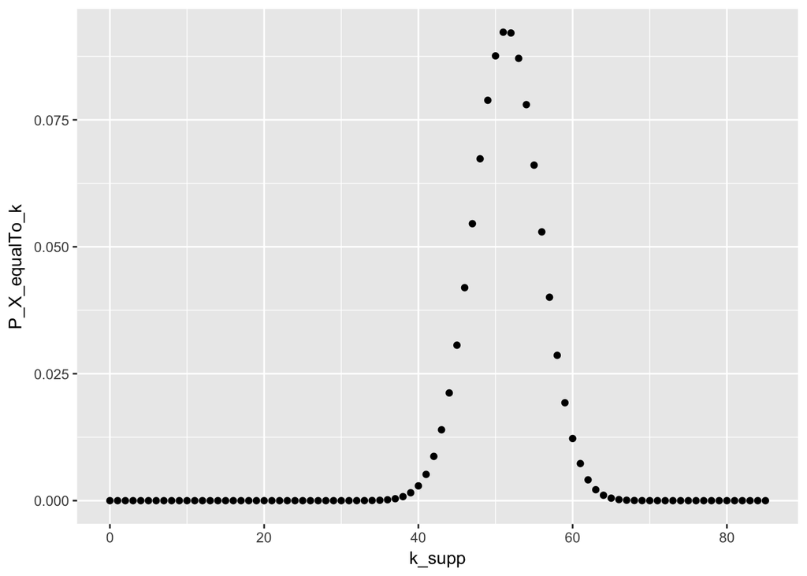

```r
# This is slightly confusing, you have to check each parameter carefully.
qplot(x = k_supp, y = P_X_equalTo_k, geom = 'point')
```

Then, we perform the p-value procedure. The p-value of a two-tailed Fisher’s exact test is

$$\sum_{P(X=x) \le P(X=o_{1,1})} P(X=x)$$

That is, the sum of the probabilities of **possible observations** with the test statistic $P(X=x)$ is lower than or equal to the test statistic of our current observation $P(X=o_{1,1})$. The algebra format of the test statistic is identical to that of the probability of the observation.

In addition, the p-value definition here is quite different from our previous definitions, such as the p-value in z-test. However, keep in mind one interpretation of p-value: “a p-value is the probability getting a result as extreme or more extreme than the event you actually did observe”. In two-tailed Fisher’s exact test, the extremeness is the probability of observing a certain data (contingency table) under $H_0$, and we sum all probabilities lower than or equal to the current observation in two-tailed test.

What makes the p-value of Fisher’s exact test more complicated is that the definition of “extremeness” when calculating one-tailed Fisher’s exact test p-value is quite different from that of two-tailed. In one-tailed test:

- If the alternative hypothesis is the odds ratio $<$ 1, the as extreme and more extreme cases are the possible observations with odds ratio lower than or equal to that of the current observation.
- If the alternative hypothesis is the odds ratio $>$ 1, the as extreme and more extreme cases are the possible observations with odds ratio greater than or equal to that of the current observation.

We leave the mathematical formula of one-tailed Fisher’s exact test p-value as “to think about” question 2.

```r
two_sided_p_val <- sum(P_X_equalTo_k[
  P_X_equalTo_k <= P_X_equalTo_k[k_supp==ds_2x2_tbl[1,1]]])
two_sided_p_val
```

```
## [1] 0.0001724037
```

```r
# Compare to fisher.test
two_sided_ref_p_val <- fisher.test(ds_2x2_tbl, alternative='two.sided')$p.val
two_sided_ref_p_val
```

```
## [1] 0.0001724037
```

```r
all.equal(two_sided_p_val, two_sided_ref_p_val)
```

```
## [1] TRUE
```

```r
# alternative hypothesis is less than
one_sided_ahl_p_val <- sum(P_X_equalTo_k[k_supp <= ds_2x2_tbl[1, 1]])
one_sided_ahl_p_val
```

```
## [1] 0.0001252688
```

```r
one_sided_ahl_ref_p_val <- fisher.test(ds_2x2_tbl, alternative='l')$p.val
one_sided_ahl_ref_p_val
```

```
## [1] 0.0001252688
```

```r
all.equal(one_sided_ahl_p_val, one_sided_ahl_ref_p_val)
```

```
## [1] TRUE
```

```r
# alternative hypothesis is greater than
one_sided_ahg_p_val <- sum(P_X_equalTo_k[k_supp >= ds_2x2_tbl[1, 1]])
one_sided_ahg_p_val
```

```
## [1] 0.9999502
```

```r
one_sided_ahg_ref_p_val <- fisher.test(ds_2x2_tbl, alternative='g')$p.val
one_sided_ahg_ref_p_val
```

```
## [1] 0.9999502
```

```r
all.equal(one_sided_ahg_p_val, one_sided_ahg_ref_p_val)
```

```
## [1] TRUE
```

## 3.4 To think about

1. Why the sum of one-tail p-values is not 1? Why the p-value of two-tailed test is not equal to any of the one-tailed test? Hint: check the p-value calculation procedure.
2. What are the mathematical formulas of one-tailed Fisher’s exact test p-values? The alternative hypotheses of one-tailed Fisher’s exact test can be `less` or `greater` when calling the function `fisher.test`.
3. In `ds_2x2_tbl`, if we only change $o_{1, 1}$ and $o_{2, 1}$ but not their sums, what are all possible changes? Among these changes, which ones have odds ratios bigger than 1? What are the probabilities of observing them if the null hypothesis is true? What is the relationship between these probabilities and the probability mass function of our test statistic? Example changed `ds_2x2_tbl`:

```
##
##             disease non-disease
##   non-smoke      30         500
##   smoke          55         300
```

4. Rearrange the `ds_2x2_tbl` table in at least two different ways, e.g. making “smoke” as the first row and non-disease as the first column, and then perform two-tailed Fisher exact test on the rearranged table. Are the p-values different from the original one? Why? Hint: check how the test statistic $P$ is calculated. Example rearranged `ds_2x2_tbl`:

```
##
##               non-smoke smoke
##   disease            35    50
##   non-disease       500   300
```

# 4 McNemar’s Test

McNemar’s test is basically a paired version of Chi-square test. For example, you asked whether the participants liked the device before and after the experiment:

```
                After experiment
                     Yes   No
```

Here, what you want to test is whether the number of the participants who liked the device were significantly changed between before and after the experiment.

Effect size -> The effect size of the Fisher’s exact test can be calculated in the same way as the one for the Chi-square test.

```r
data <- matrix(c(6, 2, 8, 4), ncol=2, byrow=T)
mcnemar.test(data)
```

```
##
##  McNemar's Chi-squared test with continuity correction
##
## data:  data
## McNemar's chi-squared = 2.5, df = 1, p-value = 0.1138
```

Example taken from http://yatani.jp/teaching/doku.php?id=hcistats:chisquare.

# 5 Kolmogorov-Smirnov Test

Generate data for KS test

```r
x <- rnorm(50)
y <- runif(30)
```

Does distributions x and y come from the same distribution?

Ho = Distributions come from the same distributions Ha = Distributions come from different distributions

```r
ks.test(x,y)
```

```
##
##  Two-sample Kolmogorov-Smirnov test
##
## data:  x and y
## D = 0.48, p-value = 0.0002033
## alternative hypothesis: two-sided
```

The default KS test is two sided. What about one-sided?

```r
ks.test(x, y, alternative = "less")
```

```
##
##  Two-sample Kolmogorov-Smirnov test
##
## data:  x and y
## D^- = 0.20667, p-value = 0.2016
## alternative hypothesis: the CDF of x lies below that of y
```

```r
ks.test(x, y, alternative = "greater")
```

```
##
##  Two-sample Kolmogorov-Smirnov test
##
## data:  x and y
## D^+ = 0.48, p-value = 0.0001769
## alternative hypothesis: the CDF of x lies above that of y
```

**To think about** We are clearly simulating data from different distributions (normal and uniform), but the KS test below does not result in a significant p-value. Why?

```r
x <- rnorm(10)
y <- runif(6)
ks.test(x, y)
```

```
##
##  Two-sample Kolmogorov-Smirnov test
##
## data:  x and y
## D = 0.53333, p-value = 0.1701
## alternative hypothesis: two-sided
```

## 5.1 qqplots

Generate data to assess normality

```r
x <- rnorm(500)
y <- runif(300)
```

Now that we have simulated data and stored them in variables x and y, let’s assess normality.

Is “x” normally distributed?

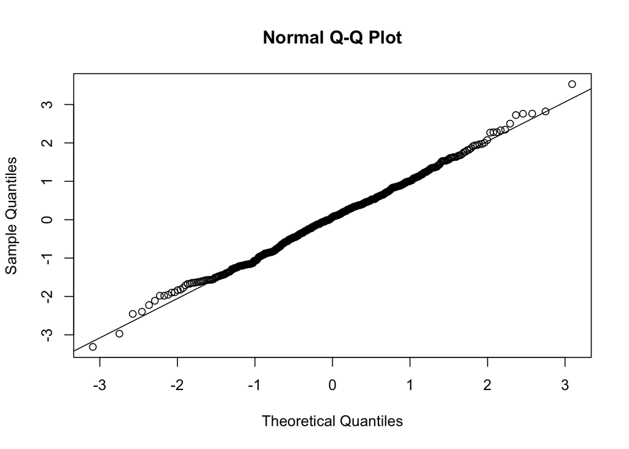

```r
qqnorm(x)
qqline(x)
```

What about “y”? How do you expect the plots to look like?

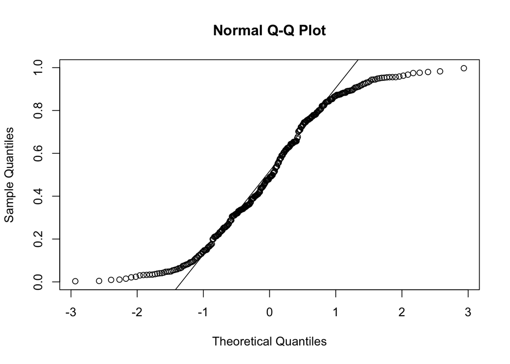

```r
qqnorm(y)
qqline(y)
```

**To think about** Sometimes qqplots may be difficult to interpret, how else could you visualize the distributions in addition to qqplots?

# Homework Questions

Create a new R Markdown file for submitting this assignment. You should submit both your knit file in HTML and the original Rmd file to the Week 5 homework submission link in CANVAS.

1. You obtain RNA-seq data. You get countTable of the all the genes expressed from a cancer patient with acute lymphoblastic leuekmia (CD19+ cells) and from a control (normal) sample. You are asked to compare the distributions.

What would be the first step? And how would you do it (in R)?

2. You see an asymmetrical distribution in your data. Why do you see this (biologically)?

What test would you use to make the comparison?

3. Using packages e1071 in R, what functions would you use to measure the skew of these datasets?
4. You are a given multiple sets of samples and you plot a histogram and you realize that for a subset of genes the shape of the distribution is always flat or Uniform.

What genes are these and why do you think so?

# 6 REFERENCES

[1] K. P. F.R.S, “X. On the criterion that a given system of deviations from the probable in the case of a correlated system of variables is such that it can be reasonably supposed to have arisen from random sampling,” The London, Edinburgh, and Dublin Philosophical Magazine and Journal of Science, vol. 50, no. 302, pp. 157–175, Jul. 1900.

[2] “Chi-squared test,” Wikipedia, Feb. 2018.

[3] “Joint probability distribution,” Wikipedia, Oct. 2017.

[4] “9.1 - Chi-Square Test of Independence | STAT 500.” https://onlinecourses.science.psu.edu/stat500/node/56.

[5] R. A. Fisher, “On the Interpretation of XX2 from Contingency Tables, and the Calculation of P,” Journal of the Royal Statistical Society, vol. 85, no. 1, pp. 87–94, 1922.

[6] “Fisher’s exact test,” Wikipedia, Jan. 2018.

[7] W. W. Hauck, “A Comparative Study of Conditional Maximum Likelihood Estimation of a Common Odds Ratio,” Biometrics, vol. 40, no. 4, pp. 1117–1123, 1984.

[8] “3.3 - Two-way Tables - Exact Tests | STAT 504.” https://onlinecourses.science.psu.edu/stat504/node/89.

[9] “Contingency table,” Wikipedia, Feb. 2018.

[10] “Comparing Two Proportions | STAT 414 / 415.” https://onlinecourses.science.psu.edu/stat414/node/268.

[11] “8.1 - Comparing Two Population Proportions with Independent Samples | STAT 500.” https://onlinecourses.science.psu.edu/stat500/node/55.

[12] A. Agresti, “A Survey of Exact Inference for Contingency Tables,” Statistical Science, vol. 7, no. 1, pp. 131–153, Feb. 1992.

[13] “Cartesian product,” Wikipedia, Nov. 2017.

[14] “Hypergeometric distribution,” Wikipedia, Jan. 2018.

[15] “Hypothesis testing - Is ‘test statistic’ a value or a random variable? - Cross Validated.” https://stats.stackexchange.com/questions/85426/is-test-statistic-a-value-or-a-random-variable.

[16] “Exact test,” Wikipedia, Aug. 2017.

[17] “Hypergeometric Distribution | STAT 414 / 415.” https://onlinecourses.science.psu.edu/stat414/node/58.